# Exploration of Prosper Loan Data by David Shahrestani

### LoanStatus Exploration

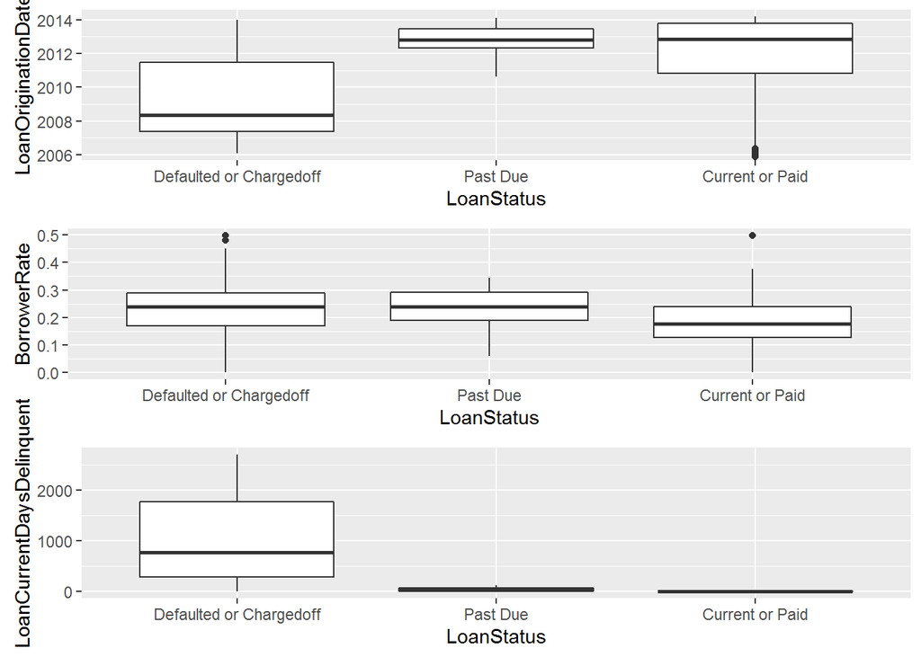

Of these features, the loan origination date appears to be the best predictor of whether a loan is current or in default.

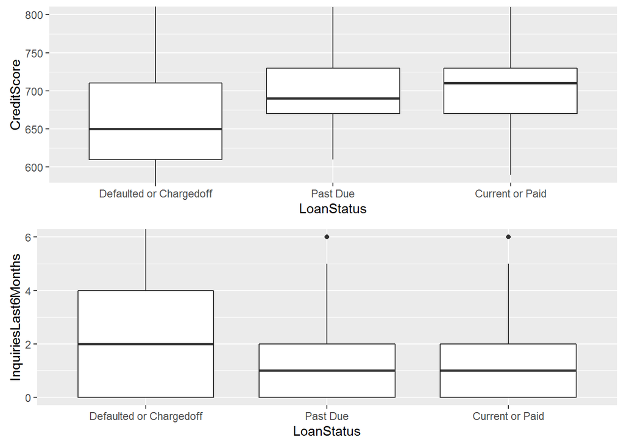

Of these features, credit score appears to be the best predictor of whether a loan is current or in default.

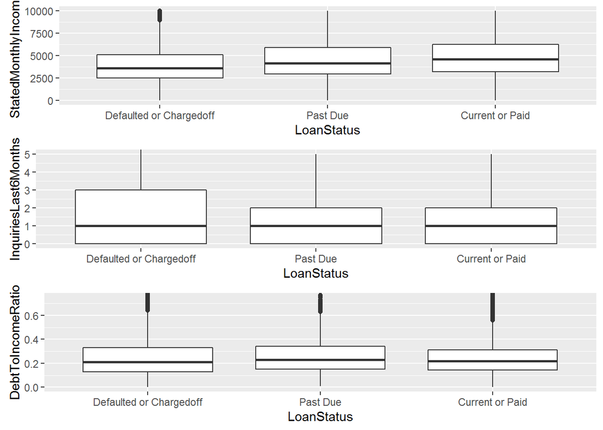

Of these features, stated monthly income is the only one that shows promise for further exploration.

### Other Exploration

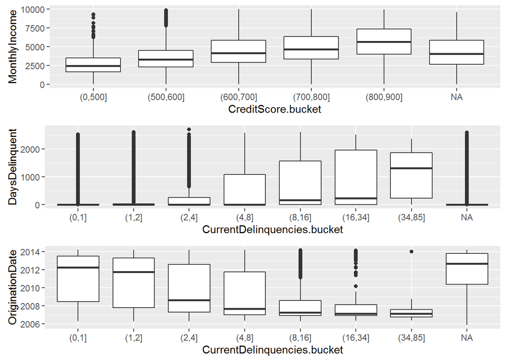

These plots explore some relationships that stood out. Credit score seems to be positively correlated with monthly income.The amount of delinquencies when the loan was originated seems to be correlated with the number of days a loan is currently delinquent. The date the loan was originated also seems to be correlated to the number of delinquencies the borrower had on their credit score. This could because of the overall economy.

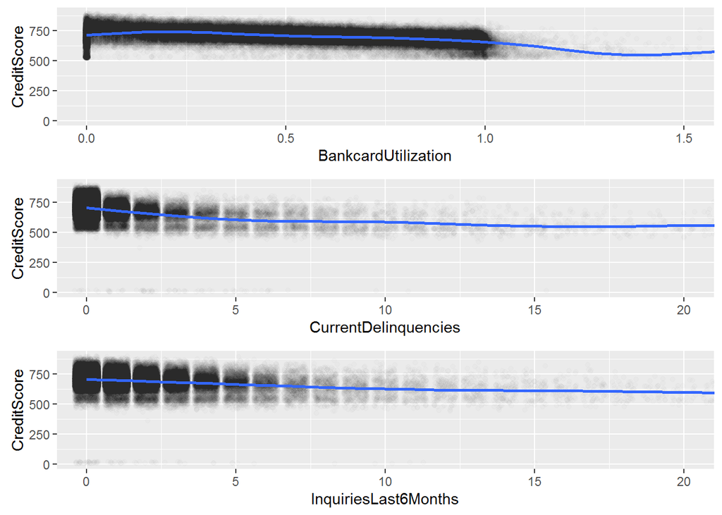

These plots show the relationship between CreditScore and other credit factors. As would be expected, credit factors tend to be correlated with credit score.

# Bivariate Analysis

### Talk about some of the relationships you observed in this part of the investigation. How did the feature(s) of interest vary with other features in the dataset?

- BorrowerRate is related to CreditScore, BankCardUtilization, and IsBorrowerHomeowner.
- TimeUntilClosed is related to LoanOriginationDate, BorrowerRate, ListingCategory, and Term.
- Loan Status is related to LoanOriginationDate, BorrowerRate, and Credit Score and Term.

### Did you observe any interesting relationships between the other features (not the main feature(s) of interest)?

- Creditscore is positively related to StatedMonthlyIncome.
- LoanOriginationDate is related to CurrentDelinquencies. This could be because of the change in the overall health of the economy over time. *LoanCurrentDaysDelinquent is related to CurrentDelinquencies at the time of loan origination.
- CreditScore is related to all other credit factors, as would be expected.

### What was the strongest relationship you found?

The strongest relationship found is between LoanStatus and LoanCurrentDaysDelinquent. The correlation was -.766 and it is both obvious and meaningless in relation to the broader analysis of this data.

```
##
##  Pearson's product-moment correlation
##
## data:  as.numeric(LoanStatus) and LoanCurrentDaysDelinquent
## t = -402.72, df = 113930, p-value < 2.2e-16
## alternative hypothesis: true correlation is not equal to 0
## 95 percent confidence interval:
##  -0.7687888 -0.7639968
## sample estimates:
##        cor
## -0.7664035
```

# Multivariate Plots Section

### BorrowerRate Exploration

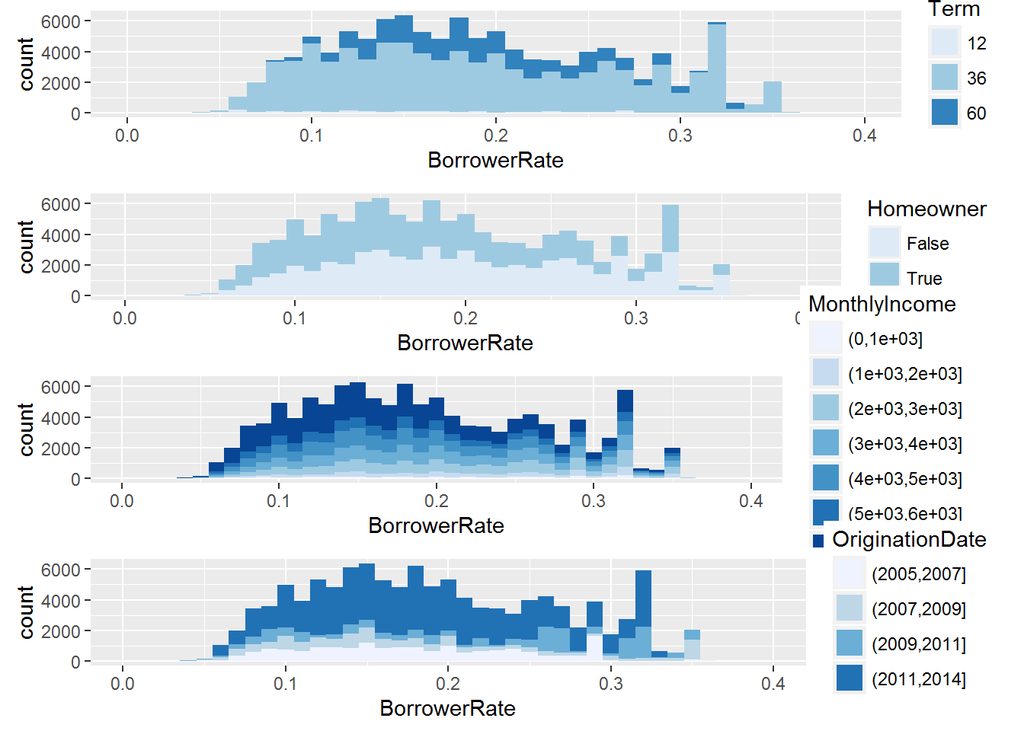

I wanted to isolate the spike in BorrowerRates that was discovered earlier. I started with this group of histograms to get a bigger picture view of the distribution. Term and LoanOriginationDate both stand out and will be investigated further in the following plot.

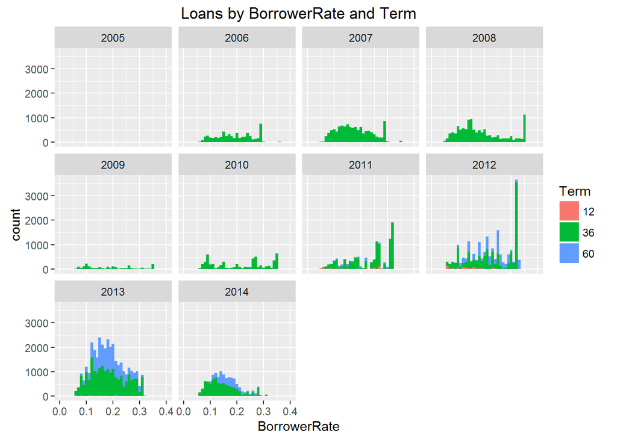

The large spike in loans with a BorrowerRate of around 32%, that was discovered earlier, seems to be explained by a large surge of 36 month loans in 2012.

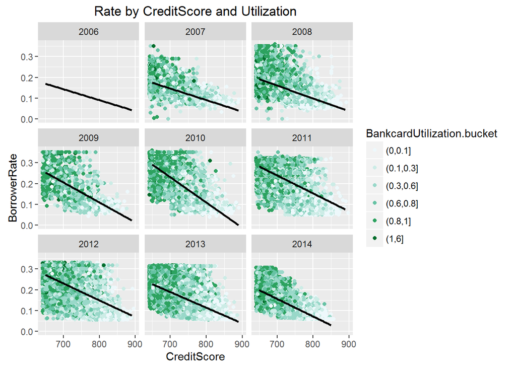

The disperson of BorrowerRates across CreditScore and BankcardUtilization larger than I would have hoped. This will add difficulty in building my model. It is interesting that some years have more disperson than others. It is possible that credit standards fluctuate between years. Sometimes accepting everyone and sometimes being picky.

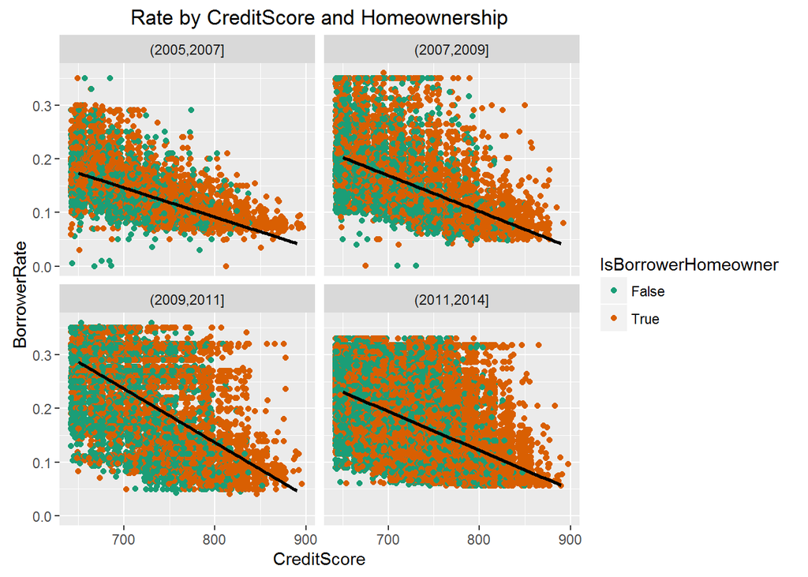

Adding homeownership to the plot does not create a clearer picture. It does not seem that BorrowerRate is dependent on whether one owns a home.

```
##
## Calls:
## m1: lm(formula = BorrowerRate ~ CreditScore, data = subset(df, CreditScore >=
##     640))
## m2: lm(formula = BorrowerRate ~ CreditScore + BankcardUtilization,
##     data = subset(df, CreditScore >= 640))
## m3: lm(formula = BorrowerRate ~ CreditScore + BankcardUtilization +
##     IsBorrowerHomeowner, data = subset(df, CreditScore >= 640))
## m4: lm(formula = BorrowerRate ~ CreditScore + BankcardUtilization +
##     IsBorrowerHomeowner + Term, data = subset(df, CreditScore >=
##     640))
## m5: lm(formula = BorrowerRate ~ CreditScore + BankcardUtilization +
##     IsBorrowerHomeowner + Term + LoanOriginationDate, data = subset(df,
##     CreditScore >= 640))
##
## ==========================================================================================
##                                       m1         m2         m3         m4         m5
## ------------------------------------------------------------------------------------------
##   (Intercept)                       0.711***   0.686***   0.688***   0.684***   0.649***
##                                    (0.003)    (0.004)    (0.004)    (0.004)    (0.006)
##   CreditScore                      -0.001***  -0.001***  -0.001***  -0.001***  -0.001***
##                                    (0.000)    (0.000)    (0.000)    (0.000)    (0.000)
##   BankcardUtilization                          0.012***   0.012***   0.011***   0.010***
##                                               (0.001)    (0.001)    (0.001)    (0.001)
##   IsBorrowerHomeowner: True/False                         0.001      0.000      0.001
##                                                          (0.000)    (0.000)    (0.000)
##   Term: .L                                                           0.024***   0.024***
##                                                                     (0.001)    (0.001)
##   Term: .Q                                                          -0.007***  -0.008***
##                                                                     (0.001)    (0.001)
##   LoanOriginationDate                                                           0.000***
##                                                                                (0.000)
## ------------------------------------------------------------------------------------------
##   R-squared                              0.2        0.2        0.2        0.2        0.2
##   adj. R-squared                         0.2        0.2        0.2        0.2        0.2
##   sigma                                  0.1        0.1        0.1        0.1        0.1
##   F                                  27819.5    13827.9     9219.7     5687.7     4752.0
##   p                                      0.0        0.0        0.0        0.0        0.0
##   Log-likelihood                    130415.9   126695.0   126696.3   126998.1   127026.7
##   Deviance                             412.9      400.8      400.8      398.3      398.1
##   AIC                              -260825.8  -253381.9  -253382.7  -253982.3  -254037.4
##   BIC                              -260797.3  -253344.0  -253335.3  -253916.0  -253961.7
##   N                                  98805      95968      95968      95968      95968
## ==========================================================================================
```

My R-squared is .2, suggesting that only 20% of the variance in the BorrowerRate can be explained by these features. I can conclude that this model has little predictive power.

### TimeUntilClosed Exploration

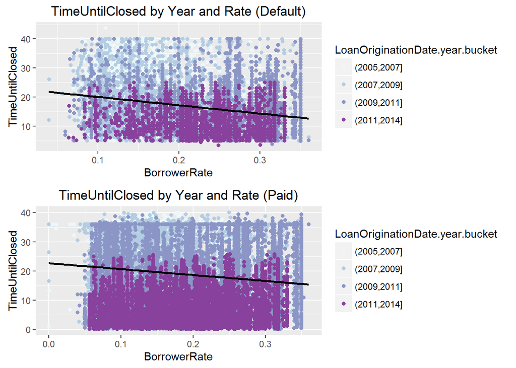

These plots show TimeUntilClosed, subsetted by loan status, vs BorrowerRate and Year. No strong relationship was found between TimeUntilClosed and BorrowerRate. Loans that were originated more recently tend to close faster, but that is intuitive.

```
##
## Calls:
## m1: lm(formula = TimeUntilClosed ~ BorrowerRate, data = df1)
## m2: lm(formula = TimeUntilClosed ~ BorrowerRate + Term, data = df1)
## m3: lm(formula = TimeUntilClosed ~ BorrowerRate + Term + CreditScore,
##     data = df1)
## m4: lm(formula = TimeUntilClosed ~ BorrowerRate + Term + CreditScore +
##     IsBorrowerHomeowner, data = df1)
## m5: lm(formula = TimeUntilClosed ~ BorrowerRate + Term + CreditScore +
##     IsBorrowerHomeowner + LoanOriginationDate, data = df1)
##
## ===============================================================================================
##                                        m1          m2          m3          m4          m5
## -----------------------------------------------------------------------------------------------
##   (Intercept)                       22.928***   19.447***   27.750***   28.127***   59.759***
##                                     (0.244)     (0.388)     (1.468)     (1.471)     (2.082)
##   BorrowerRate                     -28.658***  -27.715***  -29.640***  -29.264***  -12.600***
##                                     (1.054)     (1.046)     (1.094)     (1.098)     (1.336)
##   Term: .L                                       3.094***    3.248***    3.163***    2.902***
##                                                 (0.665)     (0.665)     (0.665)     (0.651)
##   Term: .Q                                      -4.542***   -4.465***   -4.381***   -2.311***
##                                                 (0.390)     (0.389)     (0.390)     (0.394)
##   CreditScore                                               -0.011***   -0.012***    0.001
##                                                             (0.002)     (0.002)     (0.002)
##   IsBorrowerHomeowner: True/False                                        0.623***    0.076
##                                                                         (0.162)     (0.160)
##   LoanOriginationDate                                                               -0.003***
##                                                                                     (0.000)
## -----------------------------------------------------------------------------------------------
##   R-squared                              0.1         0.1         0.1         0.1         0.1
##   adj. R-squared                         0.1         0.1         0.1         0.1         0.1
##   sigma                                  8.2         8.1         8.1         8.1         7.9
##   F                                    739.3       334.0       259.9       211.2       257.2
##   p                                      0.0         0.0         0.0         0.0         0.0
##   Log-likelihood                    -37090.2    -36968.7    -36951.6    -36944.1    -36727.1
##   Deviance                          704569.1    688506.2    686266.5    685299.8    657641.5
##   AIC                                74186.5     73947.5     73915.1     73902.3     73470.2
##   BIC                                74208.2     73983.8     73958.7     73953.1     73528.3
##   N                                  10536       10536       10536       10536       10536
## ===============================================================================================
```

My R-squared is .1, suggesting that only 10% of the variance in the TimeUntilClosed can be explained by these features. I can conclude that this model has little predictive power.

### LoanStatus Exploration

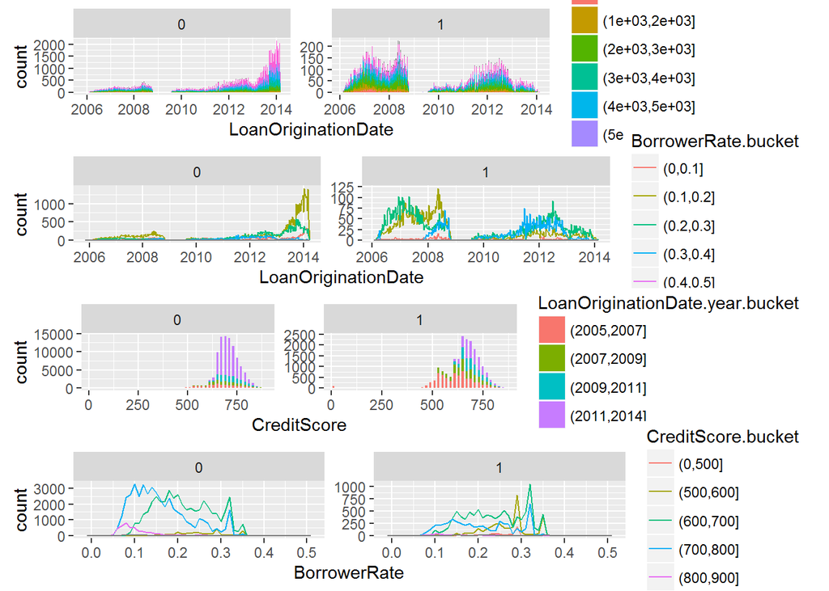

I started this exploration by looking at histogram distributions and hopeing to find a pattern. 0 Represents loans that are current or paid and 1 represents loans that are past due, defaulted, or chargedoff. A greater porportion of troubled loans have older origination dates, larger Borrower Rates, and more credit scores in the 500s.

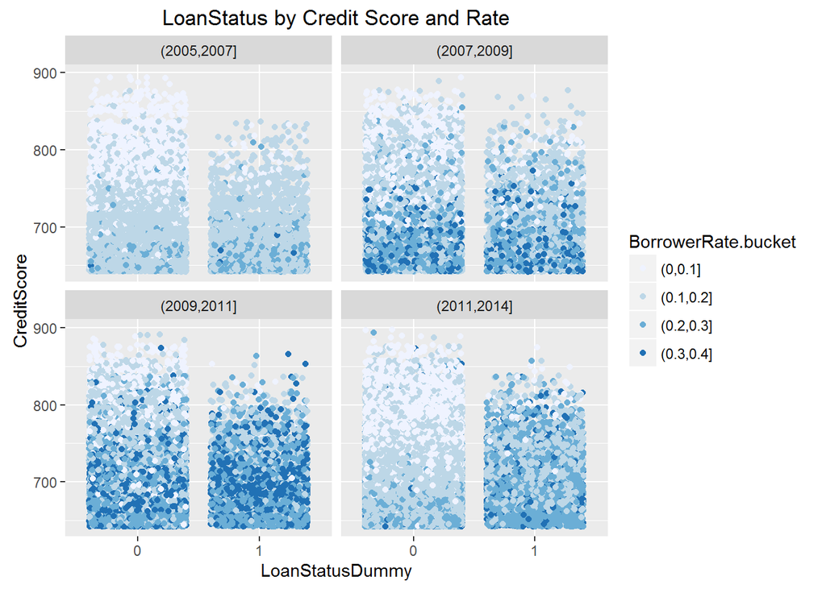

This plot shows the diffrent buckets of credits scores and borrower rates for loans that are current or paid (0) and for loans that are past due, defaulted, or chargedoff (1). They are isolated by similar origination dates. The main thing that stands out is that extremely high credit scores rarely default. Also extremely low borrower rates rarely default.

```
##
## Calls:
## m1: glm(formula = LoanStatusDummy ~ LoanOriginationDate, family = "binomial",
##     data = df)
## m2: glm(formula = LoanStatusDummy ~ LoanOriginationDate + BorrowerRate,
##     family = "binomial", data = df)
## m3: glm(formula = LoanStatusDummy ~ LoanOriginationDate + BorrowerRate +
##     StatedMonthlyIncome.bucket, family = "binomial", data = df)
## m4: glm(formula = LoanStatusDummy ~ LoanOriginationDate + BorrowerRate +
##     StatedMonthlyIncome.bucket + CreditScore, family = "binomial",
##     data = df)
##
## ======================================================================================================
##                                                              m1         m2         m3         m4
## ------------------------------------------------------------------------------------------------------
##   (Intercept)                                             13.041***  12.930***  12.804***  13.002***
##                                                           (0.130)    (0.141)    (0.149)    (0.154)
##   LoanOriginationDate                                     -0.001***  -0.001***  -0.001***  -0.001***
##                                                           (0.000)    (0.000)    (0.000)    (0.000)
##   BorrowerRate                                                        9.928***   9.716***   9.638***
##                                                                      (0.121)    (0.124)    (0.139)
##   StatedMonthlyIncome.bucket: (1e+03,2e+03]/(0,1e+03]                            0.103      0.096
##                                                                                 (0.061)    (0.061)
##   StatedMonthlyIncome.bucket: (2e+03,3e+03]/(0,1e+03]                            0.093      0.086
##                                                                                 (0.056)    (0.057)
##   StatedMonthlyIncome.bucket: (3e+03,4e+03]/(0,1e+03]                           -0.055     -0.061
##                                                                                 (0.057)    (0.057)
##   StatedMonthlyIncome.bucket: (4e+03,5e+03]/(0,1e+03]                           -0.119*    -0.124*
##                                                                                 (0.057)    (0.057)
##   StatedMonthlyIncome.bucket: (5e+03,6e+03]/(0,1e+03]                           -0.172**   -0.182**
##                                                                                 (0.060)    (0.060)
##   StatedMonthlyIncome.bucket: (6e+03,1.75e+06]/(0,1e+03]                        -0.236***  -0.236***
##                                                                                 (0.056)    (0.056)
##   CreditScore                                                                              -0.000
##                                                                                            (0.000)
## ------------------------------------------------------------------------------------------------------
##   Aldrich-Nelson R-sq.                                         0.1        0.2        0.2        0.2
##   McFadden R-sq.                                               0.1        0.2        0.2        0.2
##   Cox-Snell R-sq.                                              0.1        0.2        0.2        0.2
##   Nagelkerke R-sq.                                             0.2        0.3        0.3        0.3
##   phi                                                          1.0        1.0        1.0        1.0
##   Likelihood-ratio                                         13426.2    20907.5    20913.5    20791.4
##   p                                                            0.0        0.0        0.0        0.0
##   Log-likelihood                                          -44762.1   -41021.5   -40028.5   -39707.0
##   Deviance                                                 89524.3    82043.1    80057.0    79414.1
##   AIC                                                      89528.3    82049.1    80075.0    79434.1
##   BIC                                                      89547.6    82078.0    80161.7    79530.3
##   N                                                       113932     113932     112538     111954
## ======================================================================================================
```

My Aldrich-Nelson R-sq. is only .2, suggesting that this model has little predictive power.

# Multivariate Analysis

### Talk about some of the relationships you observed in this part of the investigation. Were there features that strengthened each other in terms of looking at your feature(s) of interest?

When looking at BorrowerRate against CreditScore and BankcardUtilization, there is a slight relationship. Borrowers with high credit scores and low utilization tend to get the best rates.

TimeUntilClosed had very little relationship with the other features. LoanOrigination date had the strongest relationship with TimeUntilClosed, but that makes intuitive sense since older loans would experience greater passage of time.

LoanStatus had very little relationship with the other features. Older loans were more likely to be in default than newer loans. Holding credit score constant, the higher the borrower rate, the more defaults. ### Were there any interesting or surprising interactions between features?

I expected loans with higher rates would be closed faster since people would want to refinance. This was not the case. I also expected the term of the loan would better predict the life of closed loans but it did not.

### OPTIONAL: Did you create any models with your dataset? Discuss the strengths and limitations of your model.

I did, but they all had very weak predictive power. The features I choose to explore might have hindered my results. A larger analysis of all 81 variables may prove more fruitful.

# Final Plots and Summary

### Plot One

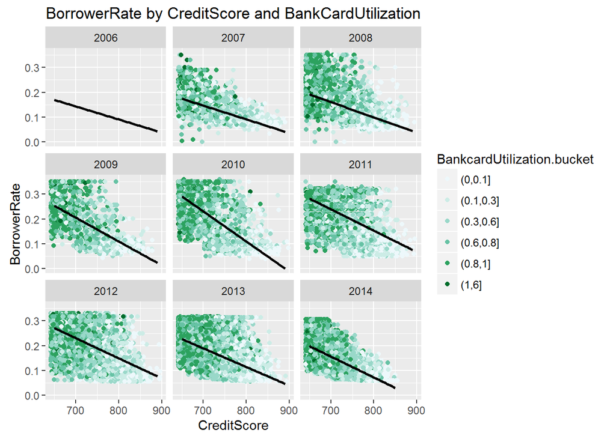

### Plot Two

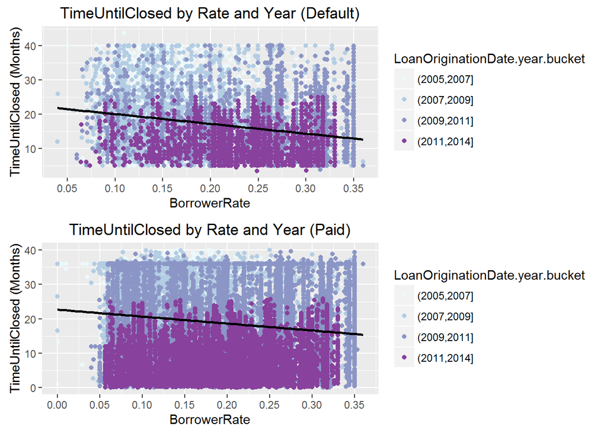

### Description Two

I would have expected the rate on a loan to affect the time until that loan is closed. This plot shows that this is not that case. Over a wide variety of BorrowerRates, the time until a loan is closed, whether for default or because it is paid, remains diverse. The plot for loans that are paid also shows a bunching around 36 and 12 months. This makes sense since those correspond to the term of the loans at origination. The lack of 60 month closing times is probably a result of not enough time having passed since inception.

### Plot Three

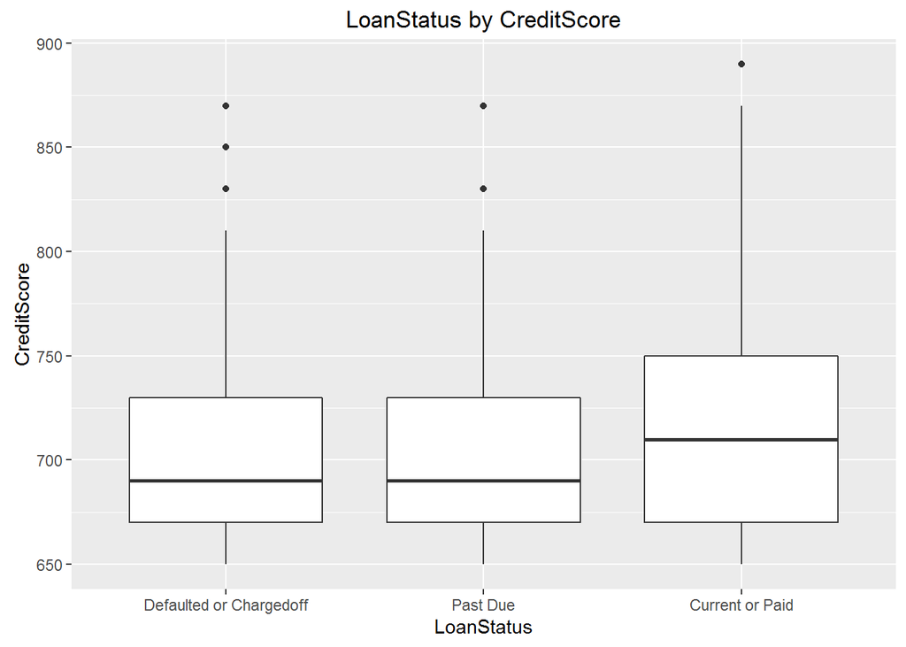

### Description Three

What stands out here is the lack of loans with extremely high CreditScores in the defaulted or charged off bin. However, when moving past those extremes, the dispersion of data doesn’t reveal much other than that loans that are current or paid have higher median credit scores. The best insight to take away is that people with amazing credit scores will probably pay you in full, but after that it’s less certain

# Reflection

Coming into this project I expected to find numerous relationships between the Prosper loan data. I ended up finding very few powerful relationships. Of those, they were mainly obvious relationships like between credit score and other credit factors.

I had an ambition goal, to predict the BorrowerRate, TimeUntilClosed, and LoanStatus of newly originated loans. This proved too difficult, as the relationships I found were quite weak. This might have been a byproduct of the features I chose to include in the data set. Originally there were 81 features and I whittled those down to less than 20.

This was a humbling experience, and reminded me how hard data science can be. If it was easy, everyone would do it. Going forward, I plan on redoing my analysis with an even larger data set that includes even more features. I feel I have only cracked the surface of what these loan data sets hold.